# Evaluating the Knowledge of HIV/AIDS in India

Tiogouo Tezemene Kevine

2023-12-09

# India Dataset Description

For this final project, we utilized the India dataset obtained from the Demographic and Health Survey (DHS) in India. The aim of this project was to evaluate the HIV/AIDS knowledge of 632 respondents in India. The HIV knowledge within the dataset constitute of:

-**Knowledge about AIDS** (ever heard of aids)

-**Knowledge of HIV prevention** (use of condom reduce the risk of HIV, one sex partner reduce the risk of HIV)

-**Comprehensive knowledge about HIV** (mosquito bites cause HIV, sharing of food cause HIV)

-**Knowledge of prevention of mother-to-child transmission** (HIV is transmitted through pregnancy, HIV is transmitted through delivery, HIV is transmitted through breastfeed )

# 1. Knowledge about AIDS

Out of the 632 respondents, a 100% have ever heard of AIDS.

Table:

**Knowledge about AIDS**

| Ever heard of AIDS | n | percent |
| --- | --- | --- |
| no | 0 | 0 |
| yes | 632 | 1 |

The plot below shows similar information

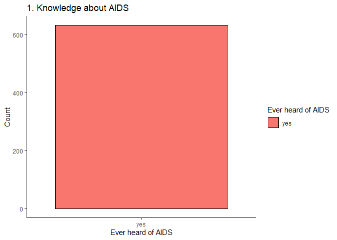

# 2. Knowledge about HIV prevention

The table below shows the responses to: the use of condom reduce the risk of HIV. A proportion of 76.74% agreed to the statement that the use of condom reduce the risk of HIV.

Table:

**Responses to: The use of condom reduce the risk of HIV**

| use of condom reduce the risk of HIV | n | percent |
| --- | --- | --- |
| no | 115 | 0.1819620 |
| yes | 485 | 0.7674051 |
| don’t know | 32 | 0.0506329 |

The table which proceeds shows the responses to: having one sex partner reduce the risk of HIV. More than half of the participants (79.27%) agreed that having one sex partner reduce the risk of HIV

Table:

**Responses to: Having one sex partner reduce the risk of HIV**

| having one sex partner reduce the risk of HIV | n | percent |
| --- | --- | --- |
| no | 104 | 0.1645570 |
| yes | 501 | 0.7927215 |
| don’t know | 27 | 0.0427215 |

## 2.1 Distribution of knowledge about HIV prevention by age group

### 2.1.1 Distribution of responses to: The use of condom reduce the risk of HIV by age group

The majority of the respondents among the different age groups agreed that the use of condom reduce the risk of HIV.

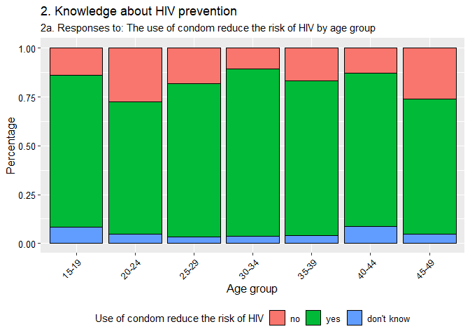

### 2.2 Distribution of responses to: Having one sex partner reduce the risk of HIV by religion

In terms of religion, all of the sikh respondents agreed that having one sex partner reduce the risk of HIV.

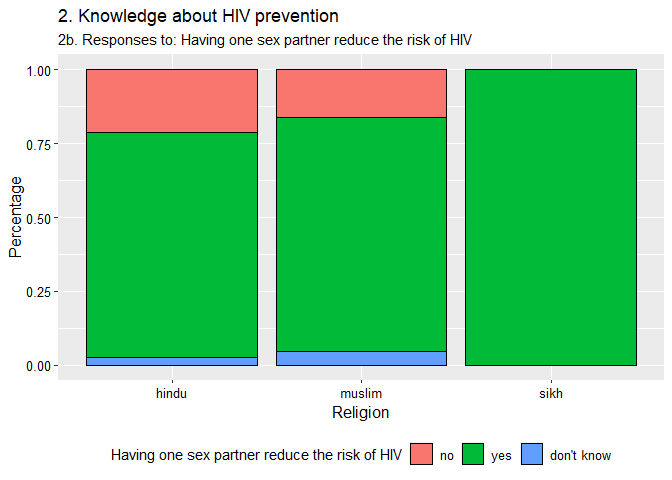

# 3. Comprehensive Knowledge about HIV

## 3.1 Distribution of comprehensive knowledge about HIV by education

### 3.1.1 Distribution of Responses to: Mosquito bites can cause HIV by education

Respondents with a primary and no education showed a poorer knowledge by agreeing to the statement that mosquito bites cause HIV as compared to those with higher and secondary education.

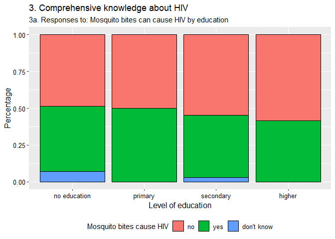

## 3.2 Distribution of comprehensive knowledge about HIV by literacy

### 3.2.1 Distribution of Responses to: Sharing food with an infected person causes HIV by literacy

More than half of the respondents showed a poor knowledge by agreeing to the statement that sharing food with an infected person cause HIV, with the highest agreement among those who could not read at all.

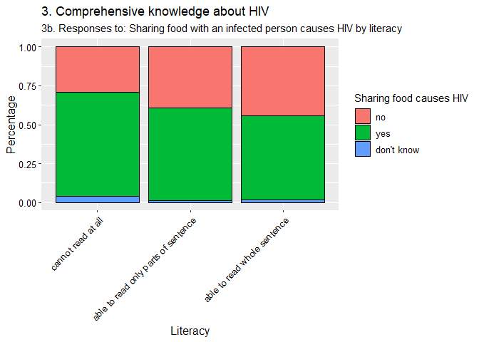

# 4. Knowledge on prevention of mother-to-child

## 4.1 Distribution of knowledge on prevention of mother-to-child transmission by wealth index

### 4.1.1 Distribution of Responses to: HIV can be transmitted during pregnancy by wealth index

The distribution across wealth index showed that more than 70% of the respondents agreed that HIV can be transmitted during pregnancy

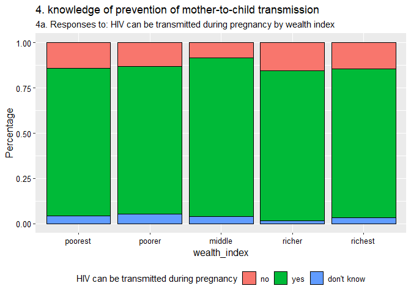

## 4.2 Distribution of knowledge on prevention of mother-to-child transmission by media

### 4.2.1 Distribution of Responses to: HIV can be transmitted during breastfeeding by frequency of watching tv

In terms of frequency of watching tv, those who watched tv at least once a week had a correct response to the statement HIV can be transmitted during breastfeeding as compared to those who watched tv less than once a week or not at all.

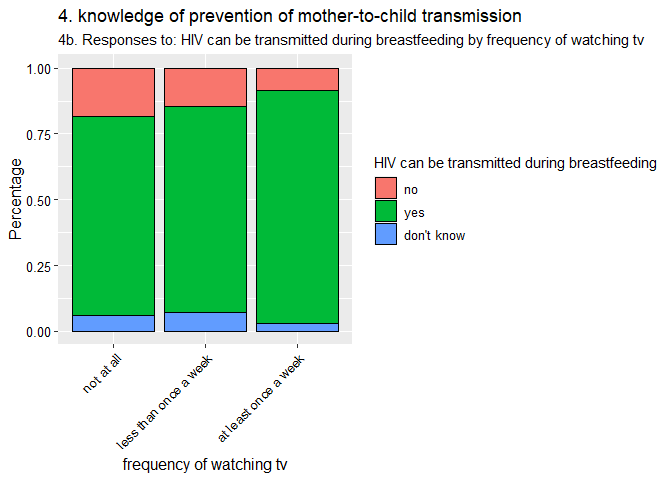

# Conclusion

While there was generally good knowledge of HIV in India, individuals with primary or no education exhibited limited knowledge concerning the misconception that mosquito bites could transmit HIV. Additionally, respondents who could only read parts of a sentence or not at all demonstrated a poor knowledge regarding the statement that sharing food with an infected person can cause HIV.